# PH784 Advanced Social Epidemiology: Methods

Week 1: Intro & Measures of Helath Disparities

Koichiro Shiba

kshiba@bu.edu

Boston University School of Public Health

September 8, 2025

## Structure

- Who am I?
- Course Overview
- Measures of Health Disparities

## Who am I?

Social epidemiologist, assistant professor

#### What I study

1. Social Determinants of Health
   1. Social connectedness
   2. Traumatic experiences
   3. Positive psychological wellbeing
2. Causal Inference

Selected articles. Social connectedness: (Shiba et al. 2021c; Nakagomi et al. 2023); Traumatic experience: (Shiba et al. 2021b, 2021a; Yazawa et al. 2022); Positive psychological well-being: (Okuzono et al. 2022)

## Past Methodology Work

- Propensity score methods: assumptions and causal estimand
- Outcome-wide study & E-values
- Causal estimand in the presence of selection bias and non-proportional hazard
- Causal effect decomposition for life course epidemiology
- Machine learning (ML) for causal inference

Selected articles. Propensity score: (Shiba and Kawahara 2021); Outcome-wide analysis: (Shiba et al. 2022b); Selection bias & non-proportional hazard (Shiba et al. 2021b); Effect decomposition (Yazawa et al. 2022)

## Social Epidemiology is Hard

### We provide scientific evidence on:

1. Health disparities (descriptive)
2. Social determinants of health (causal)

**This is hard because what we study are:**

- Invisible, multi-dimensonal
- Complex
- Hard to manipulate
- Dynamic
  - Change across time, space, and populations
- Distributional

## Methods in Social Epidemiology

[figure not shown]

- Both are critical
  - Trends in population data & depths
  - Theories shape questions, interpretation, methodology, reporting <sup>1</sup>
- This course will focus on quantitative methods
  - Not so much about statistical methods
  - More on interpretation, assumptions, applications
    - In the context of social epi
[^1]: Recommended textbook: (Krieger 2024)

## Course Overview

Topics to be covered

| Week | Topic | Description |
| --- | --- | --- |
| 1 | Descriptive | Measures of health disparity |
| 2-3 | Causal Inference | How to analyze data |
| 4 | Measurement | How to measure social constructs |
| 5 | Estimand | Questions |
| 6-7 | Interaction & Mediation | Applications in social epi |

**Goal**

- NOT to teach you every single detail
- NOT to be prescriptive
- To provide big-picture overviews of key thinking and debates
  - But with some equations
  - So you can learn more from the literature

## Evaluation

| Assessment | % Grade |
| --- | --- |
| Class Participation | 10% |
| Weekly Reading Quiz | 10% |
| Weekly Problem Set | 60% |
| Final Paper | 20% |
| Total | 100% |

- Class participation
  - In-class discussion
- Problem set
  - Data analysis in R
    - Use sample codes
    - Questions to the TA (Shivani Pande: sp2804@bu.edu)

**Prioritize learning rather than grading**

## Lecture slides

- HTML file created using `Quarto`
  - Reproducibility
  - Embedded code
- How to use
  1. Go to the shared folder
  2. Download the html file
  3. Open it in a web browser (e.g., Google Chrome)

[figure not shown]

## Descriptive Epidemiology

- A snapshot of a real-world distribution
  - Of Diseases (e.g., mortality), risk factors (e.g., smoking), etc
  - Comparisons across population, space, time
- Measure disease burden/frequency
  - mean, risk, prevalence, rate
- Motivation?
  - Identify problems
  - Assess performance
  - Monitor progress

## Example

### World Well-being Ranking

| Country | Mean |
| --- | --- |
| New Zealand | 7.71 (1) |
| Ireland | 7.67 (2) |
| Australia | 7.59 (3) |
| Canada | 7.59 (4) |
| Uzbekistan | 7.58 (5) |
| Iceland | 7.55 (6) |
| Norway | 7.52 (7) |
| United States | 7.50 (8) |
| Netherlands | 7.50 (9) |
| Indonesia | 7.50 (10) |

- Data from the Gallup World Poll (Shiba et al. 2022a)
  - 1.2 million individuals across 162 countries
- Top 10 countries with the “highest level of well-being”
  - Ranking based on country-specific average scores
    - What is missing?

**What about within-population distributions?**

## Example

### World Well-being “Equality” Ranking

| Country | Mean | Equality |
| --- | --- | --- |
| New Zealand | 7.71 (1) | 0.094 (4) |
| Ireland | 7.67 (2) | 0.096 (6) |
| Australia | 7.59 (3) | 0.100 (15) |
| Canada | 7.59 (4) | 0.099 (14) |
| Uzbekistan | 7.58 (5) | 0.097 (10) |
| Iceland | 7.55 (6) | 0.090 (2) |
| Norway | 7.52 (7) | 0.096 (7) |
| United States | 7.50 (8) | 0.107 (29) |
| Netherlands | 7.50 (9) | 0.097 (12) |
| Indonesia | 7.50 (10) | 0.098 (13) |

- Going beyond the “mean” ranking
  - Equality of the well-being measure
  - Assessed with the Gini index
- Different ranking for the degree of equality
  - e.g. United States
    - Relatively high average well-being (8th) but low equality (29th)

## Example

[figure not shown]

## Within-Population Distribution of Health

### Average is not the only way to summarize population health

- Total inequality
  - Measures: SD, Gini Index
    - Often not reported but can be informative
    - Without introducing ethical values (more on this later)
- Social group inequality
  - Disproportionate health distributions across social groups
    - “Health disparities”

## Terminology

- Health disparity
  - Common in the United States
- Health inequality
  - More often used internationally

> “Health disparities/inequalities are potentially avoidable differences in health (or in health risks that policy can influence) between groups of people who are more and less advantaged socially; these differences systematically place socially disadvantaged groups at further disadvantage on health” (Braveman 2006)

**Underlying Values?**

## Values in Health Disparity/Inequality

- Who are socially disadvantaged/advantaged?
  - often, race and ethnicity, socioeconomic status
  - gender, sexual orientation, disability
  - anything else?
- Health differences in favor of the disadvantaged group?
  - e.g., higher suicide rates among white men
    - Is this not inequality?
  - Judgement about equity

**Things to avoid**

- Publication bias (“Not worth reporting”)
- Confirmation bias (“This cannot be right”)

## Health Inequity

Health differences that are considered unfair and unjust

- Health disparity: $E[Y|SES=high]-E[Y|SES=low]$
  - Is this inquity?
    - Requires value judgements

**Distinguish disparity/inequality from inequity**

- Use the term “disparity” when referring to statistical findings
  - How do we explicitly incorporate equity values in statistical analyses?
    - “Allowable” covariates (Jackson 2021)

## Summary 1

- Go beyond averages when summarizing population health
- Total inequality
- Social group inequality
  - Health disparity/inequality
  - Health equity
    - Be mindful of underlying value judgements

**How do we quantify health disparity/inequality?**

- Defined as social group inequalities

## Measures of Social Group Inequalities

#### Pair-wise comparison: the simplest approach

- Social group $G$: Race and ethnicity (e.g., White: $G=0$ vs Black: $G=1$)
- Continuous Outcome $Y$: BMI

### Example

- $E[Y|G=1]-E[Y|G=0]$
  - The difference in mean BMI between white and black
  - This is equivalent to the “exposure-outcome association”
    - $\beta_1$ estimated via univariate regression $E[Y|G]=\beta_0 + \beta_1G$

## Example: Racial Disparity in BMI in NHANES data

```r
pacman::p_load(tidyverse, broom, tinytable, NHANES) # load packages
# Manual pair-wise comparison
NHANES |> group_by(Race1) |> summarize(mean = mean(BMI, na.rm = T), 4)
# Using regression
NHANES |> mutate(Race1 = factor(Race1, ordered = F) |> relevel(Race1, ref = "White")) |>
  lm(formula = BMI ~ Race1) |> tidy()
```

Manual pair-wise comparison

```
# A tibble: 5 × 3
  Race1     mean   `4`
  <fct>    <dbl> <dbl>
1 Black     28.1     4
2 Hispanic  26.4     4
3 Mexican   26.5     4
4 White     26.7     4
5 Other     24.4     4
```

- The estimated disparity betwee black and white of: $28.10-26.72=1.38$

Using regression

```
# A tibble: 5 × 5
  term          estimate std.error statistic  p.value
  <chr>            <dbl>     <dbl>     <dbl>    <dbl>
1 (Intercept)     26.7      0.0935   286.    0
2 Race1Black       1.38     0.235      5.88  4.30e- 9
3 Race1Hispanic   -0.349    0.316     -1.10  2.70e- 1
4 Race1Mexican    -0.220    0.255     -0.863 3.88e- 1
5 Race1Other      -2.29     0.279     -8.20  2.61e-16
```

- The estimate for `Race1Black`: $1.38$
  - Estimated association between black race (vs white) and BMI

## Pair-wise Comparison for a Binary Outcome

- Social group $G$: Race and ethnicity (e.g., White: $G=0$ vs Black: $G=1$)
- Binary Outcome $Y$: Depression
  - Measures of disease frequency
    - Prevalence (snapshot)
    - Risk, rate (onset)
  - Measures of association
    - Ratio and Difference

**Disparity measures are scale dependent**

## Diverging scenarios for absolute and relative inequality trends

[figure not shown]

- Constant absolute disparity
- Increasing relative disparity

[figure not shown]

- Decreasing absolute disparity
- Constant relative disparity

Figure 3 in (Harper and Lynch 2016)

## Example: Racial Disparity in Diabetes in NHANES data

```r
# Manual pair-wise comparison
NHANES <- NHANES |> mutate(diabetes.num = as.numeric(Diabetes=="Yes"))
NHANES |> group_by(Race1) |> summarize(prop = mean(diabetes.num, na.rm = T))
# Using linear regression
NHANES |> mutate(Race1 = factor(Race1, ordered = F) |> relevel(Race1, ref = "White")) |>
  lm(formula = diabetes.num ~ Race1) |> tidy()
```

Manual pair-wise comparison

```
# A tibble: 5 × 2
  Race1      prop
  <fct>     <dbl>
1 Black    0.111
2 Hispanic 0.0781
3 Mexican  0.0666
4 White    0.0715
5 Other    0.0834
```

- The estimated absolute disparity: $0.111-0.0715=0.0395$
- The estimated relative disparity: $\frac{0.111}{0.0715}=1.55$

Usinglinearregression

```
# A tibble: 5 × 5
  term          estimate std.error statistic  p.value
  <chr>            <dbl>     <dbl>     <dbl>    <dbl>
1 (Intercept)    0.0715    0.00336    21.3   2.20e-98
2 Race1Black     0.0391    0.00844     4.63  3.68e- 6
3 Race1Hispanic  0.00653   0.0114      0.574 5.66e- 1
4 Race1Mexican  -0.00494   0.00911    -0.543 5.87e- 1
5 Race1Other     0.0119    0.0101      1.18  2.37e- 1
```

- The estimate for `Race1Black`: $0.039$
  - Linear regression
  - Estimated prevalence difference
    - Absolute disparity

Note: Small difference in estimates due to rounding

## Example: Racial Disparity in Diabetes in NHANES data

```r
# Manual pair-wise comparison
NHANES <- NHANES |> mutate(diabetes.num = as.numeric(Diabetes=="Yes"))
NHANES |> group_by(Race1) |> summarize(prop = mean(diabetes.num, na.rm = T))
# Using poisson regression
NHANES |> mutate(Race1 = factor(Race1, ordered = F) |> relevel(Race1, ref = "White")) |>
  glm(formula = diabetes.num ~ Race1, family = "poisson") |> tidy(exp=T)
```

Manual pair-wise comparison

```
# A tibble: 5 × 2
  Race1      prop
  <fct>     <dbl>
1 Black    0.111
2 Hispanic 0.0781
3 Mexican  0.0666
4 White    0.0715
5 Other    0.0834
```

- The estimated absolute disparity: $0.111-0.0715=0.0395$
- The estimated relative disparity: $\frac{0.111}{0.0715}=1.55$

UsingPoissonregression

```
# A tibble: 5 × 5
  term          estimate std.error statistic   p.value
  <chr>            <dbl>     <dbl>     <dbl>     <dbl>
1 (Intercept)     0.0715    0.0471   -55.9   0
2 Race1Black      1.55      0.0993     4.39  0.0000112
3 Race1Hispanic   1.09      0.153      0.570 0.569
4 Race1Mexican    0.931     0.132     -0.543 0.587
5 Race1Other      1.17      0.132      1.17  0.243
```

- The estimate for `Race1Black`: $1.55$
  - Poisson regression
  - Estimated prevalence ratio
    - Relative disparity

**Which scale of inequality is your regressin model estimating?**

## Measures of Social Group Inequalities

#### Pair-wise comparison: the simplest approach

- Between-group difference via crude regression
- What if we adjust for covariates?
  - $E[Y|G=1, L]-E[Y|G=0, L]$
    - $\beta_1$ estimated via multivariable regression $E[Y|G, L]=\beta_0 + \beta_1G + L\beta$
- Adjusting for “confounders L”?
  - The “effect of race” on health
    - Debates on the interpretation (Galea and Hernán 2020)
    - We will revisit this issue later in the course
- Non-causal interpretation
  - “Inequitable disparities” after accounting for allowable covariates (Jackson 2021)

## Other Issues to Consider 1: Reference Group

[figure not shown]

Figure in: (Harper and Lynch 2005)

## Other Issues to Consider 1: Reference Group

1. Majority or most socially advantaged group
   - Involes value judgement
2. Best-off (healthiest) social group
   - Unstable if the reference group is small
3. Population average
   - Changes over tie

## Other Issues to Consider 2: Group Size

[figure not shown]

**Which is more equitable society?**

- Ignore group size?
  - Smaller weights to the advantaged
- Account for group size?
  - Can consider changing social group size over time
    - But should we discriminate against a particular group just because it is small?

## Summary 2

- Pair-wise comparison as a simple approach to assess social group inequalities
  - Same as crude associations from univariate regression
- Scales: additive vs relative
  - Different scales may provide different inequality narratives
  - Regression for a binary outcome typically reports relative inequalities
    - Report BOTH!
- Reference group and group size adjustment
  - No right or wrong answer but carefully select your approach

**Too many comparisons?**

- Reporting all pair-wise comparisons across multiple time points?
- Pair-wise comparisons for income?
  - Use summary measures to report overall social group inequalities

## Summary Measures for Social Inequalities

### Averaging social group differences

- Mean difference from a reference group
  - $1/n\times\sum_{j}|y_j-y_{ref}|$
    - Absolute inequality
    - Which group to choose as $y_{ref}$?
    - Can be weighted by group size: $\sum_{j}w_j|\bar{y_j}-y_{ref}|$
- Relative mean difference (Index of Disparity)
  - Divide the absolute measure above by $y_{ref}$
  - $\sum_{j}w_j|\bar{y_j}/y_{ref}-1|$
    - Relative inequality
    - Varying choices for $y_{ref}$ and $w_j$ across definitions and packages

**Always check what choices are made for reference group and weighting**

## Summary Measures for Social Inequalities

### Other metrics

1. Variance measures
2. Disproportionality measures
   - Theil index
3. Regression-based measures for ordered social groups
4. Population impact measures

## Summary Measures for Social Inequalities

### Regression-based measures

#### Example: Prevalence of diabetes by household income in the NHANES sample

1. Order by SES
2. Regress an outcome on ranking

```r
NHANES |> select(HHIncome, diabetes.num) |> na.omit() |>
  group_by(HHIncome) |> summarize(prop = round(mean(diabetes.num, na.rm = T), 2), n=n()) |>
  mutate(Group = row_number(), .before = HHIncome) |>
  setNames(c("Group", "Income", "Prev", "n")) |>
  tt(height = 0.1)
```

| Group | Income | Prev | n |
| --- | --- | --- | --- |
| 1 | 0-4999 | 0.07 | 182 |
| 2 | 5000-9999 | 0.11 | 250 |
| 3 | 10000-14999 | 0.12 | 537 |
| 4 | 15000-19999 | 0.10 | 515 |
| 5 | 20000-24999 | 0.10 | 605 |
| 6 | 25000-34999 | 0.08 | 945 |
| 7 | 35000-44999 | 0.10 | 851 |
| 8 | 45000-54999 | 0.06 | 776 |
| 9 | 55000-64999 | 0.07 | 615 |
| 10 | 65000-74999 | 0.09 | 521 |
| 11 | 75000-99999 | 0.06 | 1066 |
| 12 | more 99999 | 0.05 | 2200 |

## Summary Measures for Social Inequalities

### Regression-based measures

#### Example: Prevalence of diabetes by household income in the NHANES sample

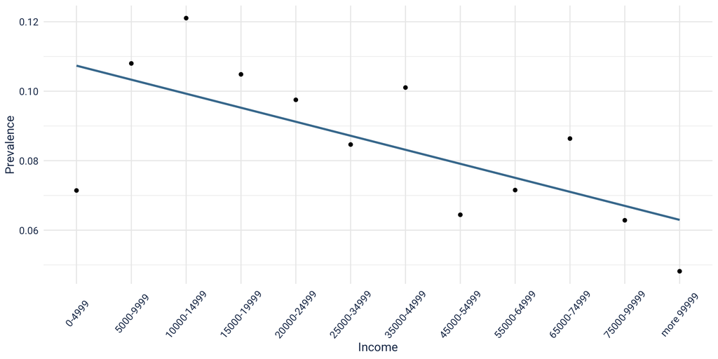

```r
df.income.db <- NHANES |> select(HHIncome, diabetes.num) |> na.omit() |>
  group_by(HHIncome) |> summarize(prop = mean(diabetes.num, na.rm = T), n=n())

df.income.db |>
  ggplot(aes(x = HHIncome, y = prop)) +
  geom_point() +
  geom_smooth(aes(group = 1), method = "lm", se = F, color = "#457b9d") +
  theme_minimal() +
  labs(x = "Income", y = "Prevalence") +
  theme(text = element_text(family = "roboto",size = 12, , colour = "#1d3557"),
        axis.text = element_text(family = "roboto",size = 10, colour = "#1d3557"),
        axis.text.x = element_text(angle=50, vjust = 0.5))
```

**Ignoring group size**

- Tricky to compare across time with changing group sizes
- Sensitive to outlier values from small groups

## Summary Measures for Social Inequalities

### Regression-based measures

#### Example: Prevalence of diabetes by household income in the NHANES sample

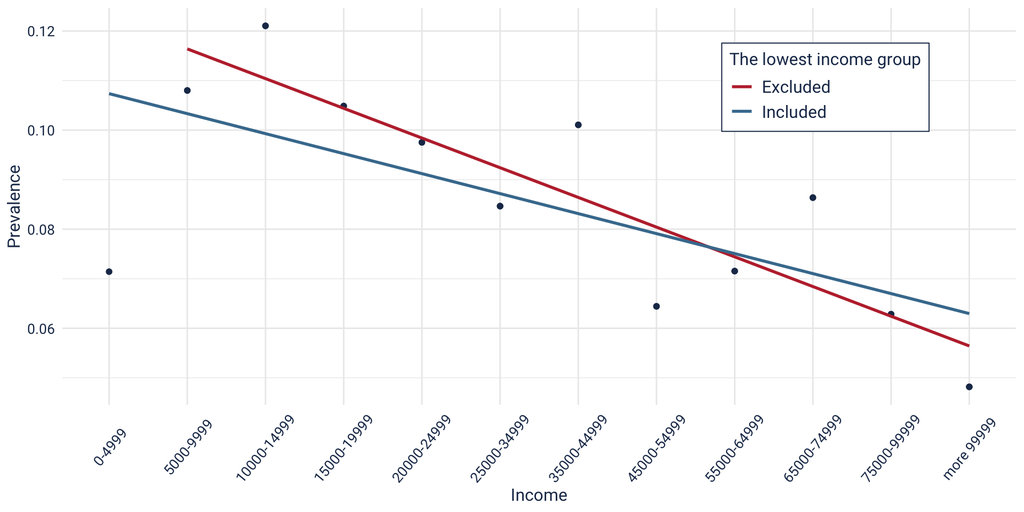

```r
df.income.db2 <- df.income.db |>
  slice(-1) |> mutate(outl = "Excluded")

df.income.db |>
  mutate(outl = "Included") |>
  bind_rows(df.income.db2) |>
  ggplot(aes(x = HHIncome, y = prop, color = outl)) +
  geom_point(color = "#1d3557") +
  geom_smooth(aes(group = outl), method = "lm", se = F) +
  scale_color_manual(name = "The lowest income group", values = c("#be2f3a", "#457b9d")) +
  theme_minimal() +
  labs(x = "Income", y = "Prevalence") +
  theme(text = element_text(family = "roboto",size = 12, , colour = "#1d3557"),
        axis.text = element_text(family = "roboto",size = 10, colour = "#1d3557"),
        axis.text.x = element_text(angle=50, vjust = 0.5),
        legend.text = element_text(family = "roboto",size = 12, colour = "#1d3557"),
        legend.title = element_text(family = "roboto",size = 12, colour = "#1d3557"),
        legend.position = "inside",
        legend.position.inside = c(0.8, 0.8),
        legend.box.background = element_rect(colour = "#1d3557"))
```

## Summary Measures for Social Inequalities

### Regression-based measures

#### Example: Prevalence of diabetes by household income in the NHANES sample

Account for the group size

1. Calculate proportions to the toal size
   - $182/n_{total}=0.02$ for Group #1
   - $250/n_{total}=0.028$ for Group #2

```r
df.income.db |>
  mutate(Group = row_number(), .before = HHIncome) |>
  mutate(
    n.prop = n/sum(n)
    ) |>
  tt(height = 0.2) |>
  setNames(c("Group","Income","Prev","n","Prop")) |>
  format_tt(digits = 2) |>
  style_tt(i = 1:2, background = "#457b9d", color = "white")
```

| Group | Income | Prev | n | Prop |
| --- | --- | --- | --- | --- |
| 1 | 0-4999 | 0.071 | 182 | 0.02 |
| 2 | 5000-9999 | 0.108 | 250 | 0.028 |
| 3 | 10000-14999 | 0.121 | 537 | 0.059 |
| 4 | 15000-19999 | 0.105 | 515 | 0.057 |
| 5 | 20000-24999 | 0.098 | 605 | 0.067 |
| 6 | 25000-34999 | 0.085 | 945 | 0.104 |
| 7 | 35000-44999 | 0.101 | 851 | 0.094 |
| 8 | 45000-54999 | 0.064 | 776 | 0.086 |
| 9 | 55000-64999 | 0.072 | 615 | 0.068 |
| 10 | 65000-74999 | 0.086 | 521 | 0.057 |
| 11 | 75000-99999 | 0.063 | 1066 | 0.118 |
| 12 | more 99999 | 0.048 | 2200 | 0.243 |

## Summary Measures for Social Inequalities

### Regression-based measures

#### Example: Prevalence of diabetes by household income in the NHANES sample

Account for the group size

1. Calculate proportions to the toal size
2. Calculate cumulative proportions
   - $0 + 0.02 = 0.02$ for Group #1
   - $0.02+0.028=0.048$ for Group #2

```r
df.income.db |>
  mutate(Group = row_number(), .before = HHIncome) |>
  mutate(
    n.prop = n/sum(n),
    n.cumprop = cumsum(n.prop)
    ) |>
  tt(height=0.2) |>
  setNames(c("Group","Income","Prev","n","Prop", "Cum")) |>
  format_tt(digits = 2) |>
  style_tt(i = 1:2, background = "#457b9d", color = "white")
```

| Group | Income | Prev | n | Prop | Cum |
| --- | --- | --- | --- | --- | --- |
| 1 | 0-4999 | 0.071 | 182 | 0.02 | 0.02 |
| 2 | 5000-9999 | 0.108 | 250 | 0.028 | 0.048 |
| 3 | 10000-14999 | 0.121 | 537 | 0.059 | 0.107 |
| 4 | 15000-19999 | 0.105 | 515 | 0.057 | 0.164 |
| 5 | 20000-24999 | 0.098 | 605 | 0.067 | 0.23 |
| 6 | 25000-34999 | 0.085 | 945 | 0.104 | 0.335 |
| 7 | 35000-44999 | 0.101 | 851 | 0.094 | 0.429 |
| 8 | 45000-54999 | 0.064 | 776 | 0.086 | 0.514 |
| 9 | 55000-64999 | 0.072 | 615 | 0.068 | 0.582 |
| 10 | 65000-74999 | 0.086 | 521 | 0.057 | 0.64 |
| 11 | 75000-99999 | 0.063 | 1066 | 0.118 | 0.757 |
| 12 | more 99999 | 0.048 | 2200 | 0.243 | 1 |

## Summary Measures for Social Inequalities

### Regression-based measures

#### Example: Prevalence of diabetes by household income in the NHANES sample

Account for the group size

1. Calculate proportions to the toal size
2. Calculate cumulative proportions
3. Regression on midpoints
   - Group #1 range: 0-0.02
     - mid=0.01
   - Group #2 range: 0.02-0.048
     - mid=0.034
     - $0.048-0.028/2$

```r
df.income.db |>
  mutate(Group = row_number(), .before = HHIncome) |>
  mutate(
    n.prop = n/sum(n),
    n.cumprop = cumsum(n.prop),
    midpoint = n.cumprop - n.prop/2
    ) |>
  tt(height=0.2) |>
  setNames(c("Group","Income","Prev","n","Prop", "Cum", "Mid")) |>
  format_tt(digits = 2) |>
  style_tt(i = 1:2, background = "#457b9d", color = "white")
```

| Group | Income | Prev | n | Prop | Cum | Mid |
| --- | --- | --- | --- | --- | --- | --- |
| 1 | 0-4999 | 0.071 | 182 | 0.02 | 0.02 | 0.01 |
| 2 | 5000-9999 | 0.108 | 250 | 0.028 | 0.048 | 0.034 |
| 3 | 10000-14999 | 0.121 | 537 | 0.059 | 0.107 | 0.077 |
| 4 | 15000-19999 | 0.105 | 515 | 0.057 | 0.164 | 0.135 |
| 5 | 20000-24999 | 0.098 | 605 | 0.067 | 0.23 | 0.197 |
| 6 | 25000-34999 | 0.085 | 945 | 0.104 | 0.335 | 0.283 |
| 7 | 35000-44999 | 0.101 | 851 | 0.094 | 0.429 | 0.382 |
| 8 | 45000-54999 | 0.064 | 776 | 0.086 | 0.514 | 0.471 |
| 9 | 55000-64999 | 0.072 | 615 | 0.068 | 0.582 | 0.548 |
| 10 | 65000-74999 | 0.086 | 521 | 0.057 | 0.64 | 0.611 |
| 11 | 75000-99999 | 0.063 | 1066 | 0.118 | 0.757 | 0.698 |
| 12 | more 99999 | 0.048 | 2200 | 0.243 | 1 | 0.879 |

## Summary Measures for Social Inequalities

### Regression-based measures

#### Example: Prevalence of diabetes by household income in the NHANES sample

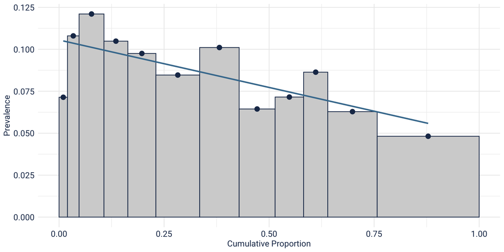

```r
df.sii <- df.income.db |>
  mutate(Group = row_number(), .before = HHIncome) |>
  mutate(
    n.prop = n/sum(n),
    n.cumprop = cumsum(n.prop),
    midpoint = n.cumprop - n.prop/2,
    left = midpoint - n.prop/2
    )

df.sii |>
  ggplot(aes(ymin=0)) +
  geom_rect(aes(xmin = left, xmax = n.cumprop, ymax = prop), colour = "#1d3557", fill = "#D3D3D3") +
  geom_point(aes(x = midpoint, y = prop), colour = "#1d3557", size = 3) +
  geom_smooth(aes(x = midpoint, y = prop), method = "lm", se = F, color = "#457b9d") +
  theme_minimal() +
  labs(x = "Cumulative Proportion", y = "Prevalence") +
  theme(text = element_text(family = "roboto",size = 12, , colour = "#1d3557"),
        axis.text = element_text(family = "roboto",size = 12, colour = "#1d3557"),
        axis.title = element_text(family = "roboto",size = 12, colour = "#1d3557"))
```

```r
df.sii |>
    lm(formula = prop ~ midpoint) |>
    tidy() |>
    tt() |>
    format_tt(digits = 2)
```

| term | estimate | std.error | statistic | p.value |
| --- | --- | --- | --- | --- |
| (Intercept) | 0.106 | 0.0075 | 14.1 | 0.000000063 |
| midpoint | -0.057 | 0.0166 | -3.4 | 0.006648294 |

- The estimated slope for `midpoint`: -0.057
  - Slope Index of Inequality (SII)
    - Summary measure of absolute inequality
  - Interpretation?
    - Absolute change in the prevalence for “one unit increase” in X
      - Moving from the bottom to the top of the income hierarchy
      - Can be flipped with reverse coded ranks

## Summary Measures for Social Inequalities

### Regression-based measures

- Regression Models
  - Grouped data: $E[Y_j|mid_j]=\beta_0 + = \beta_1mid_j$
  - Individual data: $E[Y_i|cum_i]=\beta_0 + = \beta_1cum_i$
- SII (absolute inequality): $\beta_1$
- Relative Index of Inequality (RII)
  - $SII/\bar{Y_j}$ (Pamuk 1985)
  - $\beta_0/(\beta_0 + \beta_1)$ (Kunst and Mackenbach 1994)
    - Ratio of the least vs most advantaged

**Assumptions?**

- Social groups can be ordered (e.g., income)
- Linearity
  - Can use non-linear models and predict $E[Y_i|cum_i=0]$ and $E[Y_i|cum_i=1]$

## Summary Measures for Social Inequalities

### Regression-based measures

- Simulated data with $E[Y_i|cum_i=0] = 0.2$ and $E[Y_i|cum_i=1] = 0.8$
  - True SII: $0.8-0.2=0.6$

#### Nonlinear

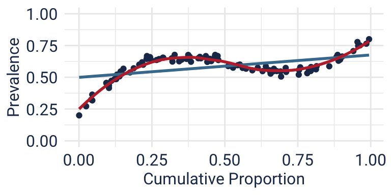

```r
set.seed(123)
x = runif(100, min = 0, max = 1)
y = 100*(x-0.5)^3 - 10*x^2 + rnorm(100, 0, 0.5) # non-linear shape
y.star = y - min(y) # rescale to start from zero
prev = 0.2 + y.star/(max(y.star)/0.6) #rescale to 0.2-0.8

coef1 <- bind_cols(x, prev) |>
  lm(formula = prev ~ x) |>
  tidy() |>
  pull(estimate)
# coef1[2] is the SII from the linear regression model

cbind(x, prev) |>
  ggplot(aes(x = x, y = prev)) +
  geom_point(colour = "#1d3557") +
  geom_smooth(method = "lm", se = F, color = "#457b9d") +
  geom_smooth(formula = y ~ x^3 + x^2, se = F, color = "#be2f3a") +
  theme_minimal() +
  labs(x = "Cumulative Proportion", y = "Prevalence") +
  scale_y_continuous(limits = c(0,1)) +
  theme(text = element_text(family = "roboto",size = 12, , colour = "#1d3557"),
        axis.text = element_text(family = "roboto",size = 12, colour = "#1d3557"),
        axis.title = element_text(family = "roboto",size = 12, colour = "#1d3557"))
```

- SII from linear regression: 0.18
  - Underestimated disparity

#### Non-monotonic

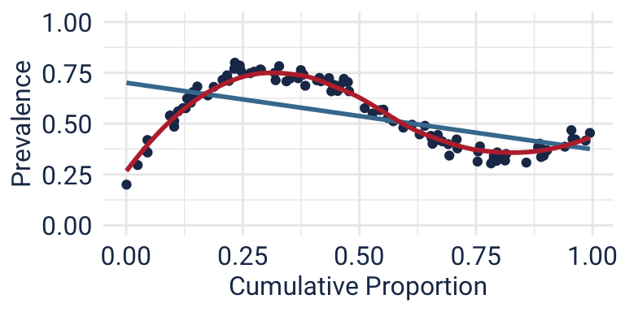

```r
set.seed(123)
x = runif(100, min = 0, max = 1)
y = 100*(x-0.5)^3 - 20*x^2 + rnorm(100, 0, 0.5) # non-linear shape
y.star = y - min(y) # rescale to start from zero
prev = 0.2 + y.star/(max(y.star)/0.6) #rescale to 0.2-0.8

coef2 <- bind_cols(x, prev) |>
  lm(formula = prev ~ x) |>
  tidy() |>
  pull(estimate)
# coef2[2] is the SII from the linear regression model

cbind(x, prev) |>
  ggplot(aes(x = x, y = prev)) +
  geom_point(colour = "#1d3557") +
  geom_smooth(method = "lm", se = F, color = "#457b9d") +
  geom_smooth(formula = y ~ x^3 + x^2, se = F, color = "#be2f3a") +
  theme_minimal() +
  labs(x = "Cumulative Proportion", y = "Prevalence") +
  scale_y_continuous(limits = c(0,1)) +
  theme(text = element_text(family = "roboto",size = 12, , colour = "#1d3557"),
        axis.text = element_text(family = "roboto",size = 12, colour = "#1d3557"),
        axis.title = element_text(family = "roboto",size = 12, colour = "#1d3557"))
```

- SII from linear regression: -0.33
  - Is the “true” SII (0.6) meaningful?

## Summary Measures for Social Inequalities

### Regression-based measures

Real-world application of SII and RII (Mackenbach et al. 2008)

[figure not shown]

## Summary Measures for Social Inequalities

### Regression-based measures

RII for education-based inequalities in all-cause mortality rate among men

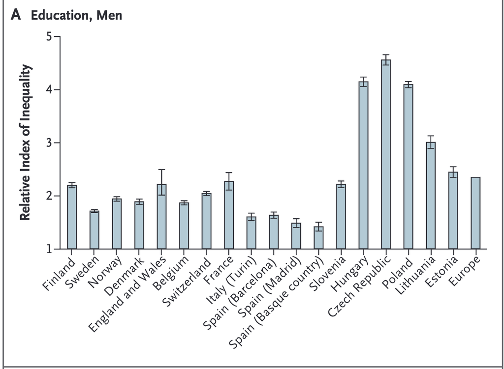

**Interpretation?**

## Summary Measures for Social Inequalities

### Impact measures

Disease rates across social groups

| SES | Rate ($Y$) | Size | Fraction |
| --- | --- | --- | --- |
| Low | 0.5 | 40 | 0.25 |
| Middle | 0.3 | 100 | 0.625 |
| High | 0.2 | 20 | 0.125 |

- Fraction: e.g., $40/(40+100+20)=0.25$
- $\bar{Y} = 0.5*0.25 + 0.3*0.625 + 0.2*0.125=0.3375$
  - Rate in the total population
- $Y_{ref} = 0.2$
  - Rate among the “best-off” group

#### Population Attributable Risk (PAR)

- Often used for disease risk factors
- $\bar{Y} - Y_{ref} = 0.3375 - 0.2= 0.1375$
  - Absolute inequality
  - “If all SES groups had the health of the high SES group, the disease rate in the population would be 0.1375 smaller.”

## Intersectionality

- Health differences across groups defined by multiple social identities
  - e.g., gender * race

**Analytic approaches for assessing intersectionality**

1. Subgroup (or regression with high-order product terms)
   - e.g., (Sawada et al. 2025)
2. Mixed effects modeling
   - MAIHDA (Evans et al. 2024)

## Summary 3

- Composite measures of social inequalities
  - Alternative to (potentially too many) pair-wise comparisons
- Mean difference from a reference group
  - Absolute and relative (Index of Dispairty)
- Regeression-based measures for ordered variables
  - SII and RII
    - Built-in weighting for group size
    - Plot the data and select a model (or use other metrics)
- Impact measures

## Assignment (due September 15th 9:59am)

- Problem set #1
  - Read the HTML file for instructions
  - Ways to submit your assignment:
  1. (Recommended) Modify the `qmd` file to include your answers
     - Then submit the rendered HTML file
       - This is a fantastic way to practice reproducible reporting using [Quarto](https://quarto.org/)!
  2. Or submit your answers as a Word document
- Reading quiz #2
  - In the blackboard course website under the “Week 2” module

## References

Braveman P. Health disparities and health equity: Concepts and measurement. Annual review of public health. 2006;27(1):167–94.

Evans CR, Leckie G, Subramanian S, Bell A, Merlo J. A tutorial for conducting intersectional multilevel analysis of individual heterogeneity and discriminatory accuracy (MAIHDA). SSM-population health. 2024;26:101664.

Galea S, Hernán MA. Win-win: Reconciling social epidemiology and causal inference. American journal of epidemiology. 2020;189(3):167–70.

Harper S, Lynch J. Methods for measuring cancer disparities: Using data relevant to healthy people 2010 cancer-related objectives. 2005;

Harper S, Lynch J. Health Inequalities: Measurement and Decomposition. SSRN Electronic Journal [Internet]. 2016; Available from: http://dx.doi.org/10.2139/ssrn.2887311

Jackson JW. Meaningful causal decompositions in health equity research: Definition, identification, and estimation through a weighting framework. Epidemiology. 2021;32(2):282–90.

Krieger N. Epidemiology and the people’s health: Theory and context. Oxford University Press; 2024.

Kunst AE, Mackenbach JP. Measuring socio-economic inequalities in health. 1994;

Mackenbach JP, Stirbu I, Roskam AJR, Schaap MM, Menvielle G, Leinsalu M, et al. Socioeconomic inequalities in health in 22 european countries. New England journal of medicine. 2008;358(23):2468–81.

Nakagomi A, Tsuji T, Saito M, Ide K, Kondo K, Shiba K. Social isolation and subsequent health and well-being in older adults: A longitudinal outcome-wide analysis. Social Science & Medicine [Internet]. 2023 Jun;327:115937. Available from: http://dx.doi.org/10.1016/j.socscimed.2023.115937

Okuzono SS, Shiba K, Kim ES, Shirai K, Kondo N, Fujiwara T, et al. Ikigai and subsequent health and wellbeing among Japanese older adults: Longitudinal outcome-wide analysis. The Lancet Regional Health - Western Pacific [Internet]. 2022 Apr;21:100391. Available from: http://dx.doi.org/10.1016/j.lanwpc.2022.100391

Pamuk ER. Social class inequality in mortality from 1921 to 1972 in england and wales. Population studies. 1985;39(1):17–31.

Sawada A, Tsuno K, Shiba K. Gender differences in subjective wellbeing in japan: An intersectionality approach. Wellbeing, Space and Society. 2025;100270.

Shiba K, Cowden RG, Gonzalez N, Lee MT, Lomas T, Lai AY, et al. Global trends of mean and inequality in multidimensional wellbeing: Analysis of 1.2 million individuals from 162 countries, 2009–2019. Frontiers in Public Health. 2022 a;10:824960.

Shiba K, Daoud A, Hikichi H, Yazawa A, Aida J, Kondo K, et al. Heterogeneity in cognitive disability after a major disaster: A natural experiment study. Science Advances [Internet]. 2021 Oct a;7(40). Available from: http://dx.doi.org/10.1126/sciadv.abj2610

Shiba K, Hikichi H, Okuzono SS, VanderWeele TJ, Arcaya M, Daoud A, et al. Long-Term Associations between Disaster-Related Home Loss and Health and Well-Being of Older Survivors: Nine Years after the 2011 Great East Japan Earthquake and Tsunami. Environmental Health Perspectives [Internet]. 2022 Jul b;130(7). Available from: http://dx.doi.org/10.1289/EHP10903

Shiba K, Kawahara T. Using Propensity Scores for Causal Inference: Pitfalls and Tips. Journal of Epidemiology [Internet]. 2021 Aug 5;31(8):457–63. Available from: http://dx.doi.org/10.2188/jea.JE20210145

Shiba K, Kawahara T, Aida J, Kondo K, Kondo N, James P, et al. Causal Inference in Studying the Long-Term Health Effects of Disasters: Challenges and Potential Solutions. American Journal of Epidemiology [Internet]. 2021 Mar 17 b;190(9):1867–81. Available from: http://dx.doi.org/10.1093/aje/kwab064

Shiba K, Torres JM, Daoud A, Inoue K, Kanamori S, Tsuji T, et al. Estimating the Impact of Sustained Social Participation on Depressive Symptoms in Older Adults. Epidemiology [Internet]. 2021 Jun 21 c;32(6):886–95. Available from: http://dx.doi.org/10.1097/EDE.0000000000001395

Yazawa A, Shiba K, Inoue Y, Okuzono SS, Inoue K, Kondo N, et al. Early childhood adversity and late-life depressive symptoms: unpacking mediation and interaction by adult socioeconomic status. Social Psychiatry and Psychiatric Epidemiology [Internet]. 2022 Feb 1;57(6):1147–56. Available from: http://dx.doi.org/10.1007/s00127-022-02241-x

Zou G. A Modified Poisson Regression Approach to Prospective Studies with Binary Data. American Journal of Epidemiology [Internet]. 2004 Apr 1;159(7):702–6. Available from: http://dx.doi.org/10.1093/aje/kwh090